# C42B cells treatment comparison

Marion Hardy

2026-01-05

# Introduction

**This report updated “Abi Tala” to “Abi Ola” double treatment.**

This report will present a broad overview of how similar/different samples are in terms of gene expression. The objective is to help AK narrow down which gene sets are of interest and follow this with a gsea analysis and a closer look at the function of these identified gene groups.This is an ongoing effort to characterize their DTP/DTEP platform and possibly understand the mechanisms underlying persistence acquisition and maintenance.

Each sample comparison shown in this report will have additional files generated:

- res_tbl.csv = all differentially expressed genes, annotated (no filtering)
- Sign_genes.xlsx = excel doc with all significantly up- and down-regulated genes (log2Fc >= 1), annotated and sorted into all genes, only up and only down on different sheets.
- volcano plot of all genes (html format)

NB: Data quality has been checked within the previous script “DESeq2.R”, everything looked good.

# PCA

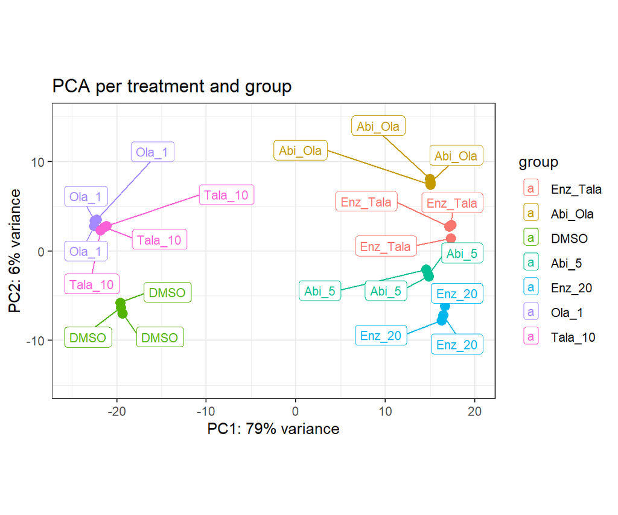

# Extract the weights per genes

Table for top 200 genes (absolute value) to weigh on PC1 and PC2.

| gene | PC | loading |
| --- | --- | --- |
| MT.RNR2 | PC1 | -5411888.88 |
| MT.CO1 | PC1 | -3670876.98 |
| MT.ND4 | PC1 | -2522683.86 |
| EEF1A1 | PC1 | -1922130.38 |
| MT.CO3 | PC1 | -1630263.32 |
| MT.CYB | PC1 | -1344374.24 |
| MT.CO2 | PC1 | -1328905.42 |
| MT.ND2 | PC1 | -1018250.34 |
| MT.ATP6 | PC1 | -1011874.29 |
| MT.ND5 | PC1 | -903593.95 |
| MT.ND1 | PC1 | -778555.89 |
| MT.RNR1 | PC1 | -682023.03 |
| EEF2 | PC1 | -596884.61 |
| MALAT1 | PC1 | -565112.24 |
| GAPDH | PC1 | -445590.81 |
| HSP90AB1 | PC1 | -432424.84 |
| PABPC1 | PC1 | -423625.89 |
| HSP90AA1 | PC1 | -402347.76 |
| EEF1G | PC1 | -384912.44 |
| HSPA8 | PC1 | -371357.15 |
| RPLP0 | PC1 | -368974.25 |
| RPL4 | PC1 | -365146.48 |
| RPS2 | PC1 | -351030.17 |
| NA..380 | PC1 | -341805.35 |
| ACTB | PC1 | -323770.18 |
| RPL3 | PC1 | -318545.58 |
| RPL13A | PC1 | -276287.18 |
| ABHD2 | PC1 | -274663.90 |
| RPS6 | PC1 | -268128.32 |
| RPL6 | PC1 | -267841.20 |

[output cut: 370 more lines]

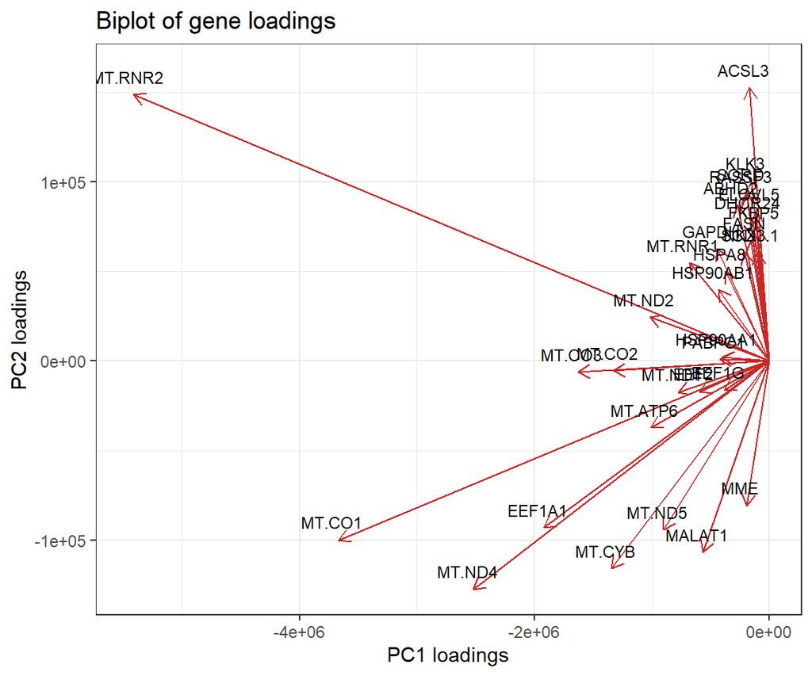

# Euclidian distances

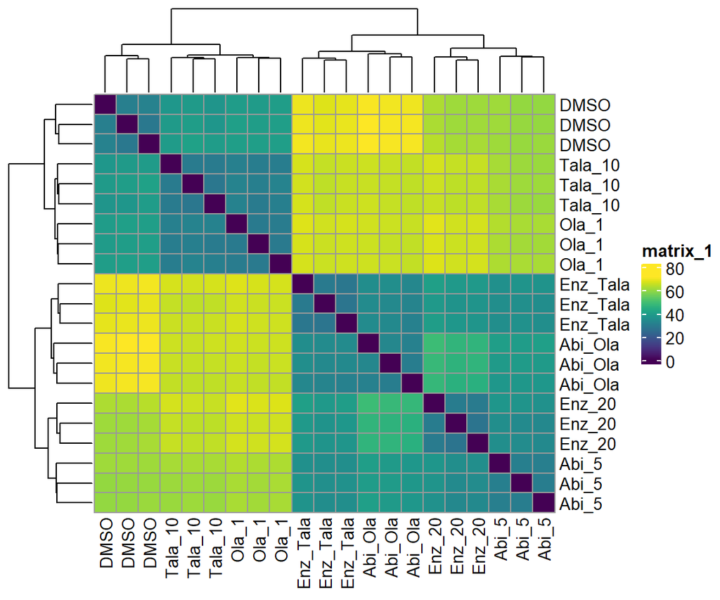

# Dendogram

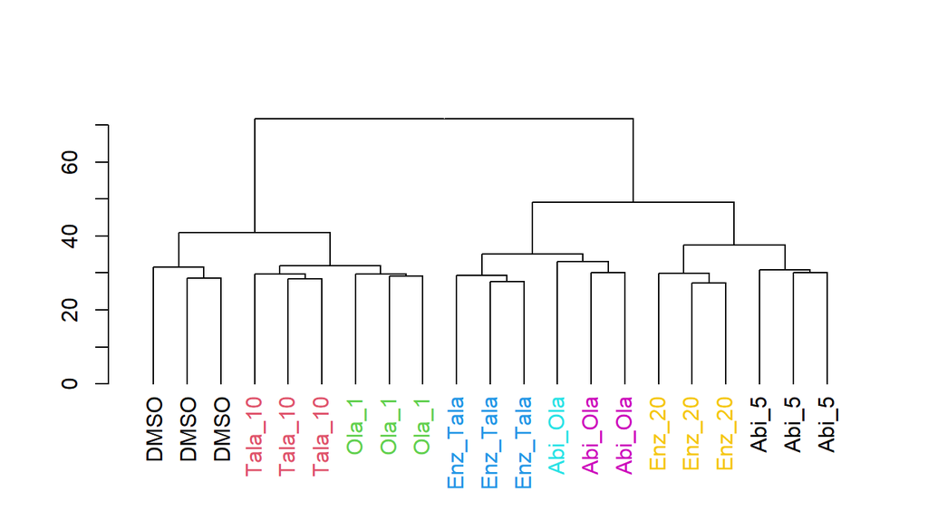

# Every treatment compared to DMSO

## Volcano plots

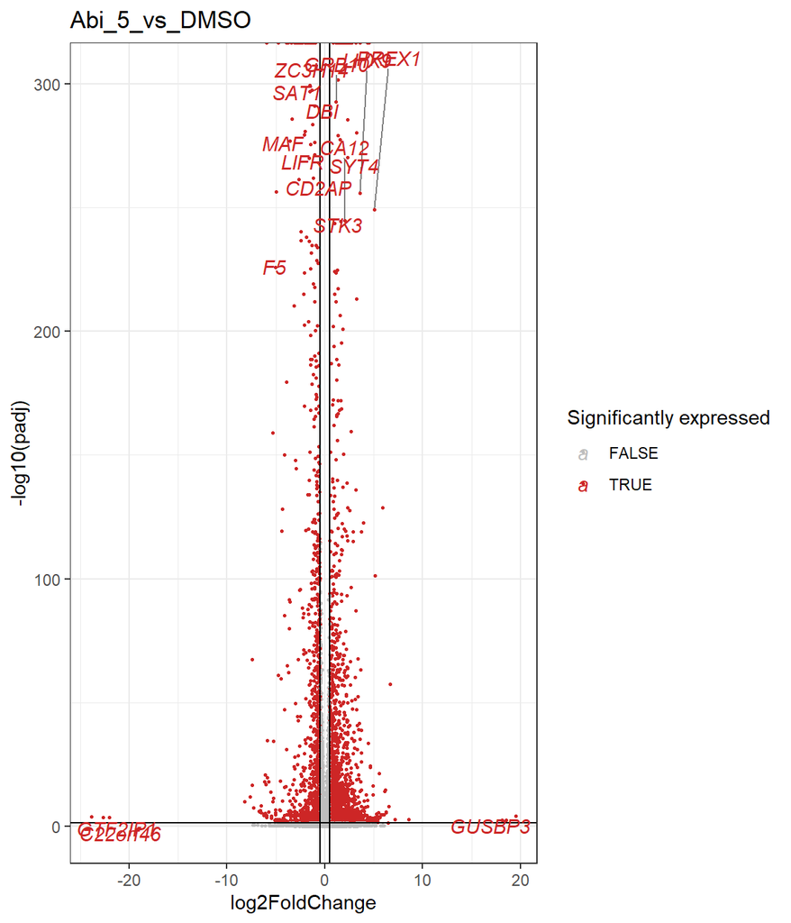

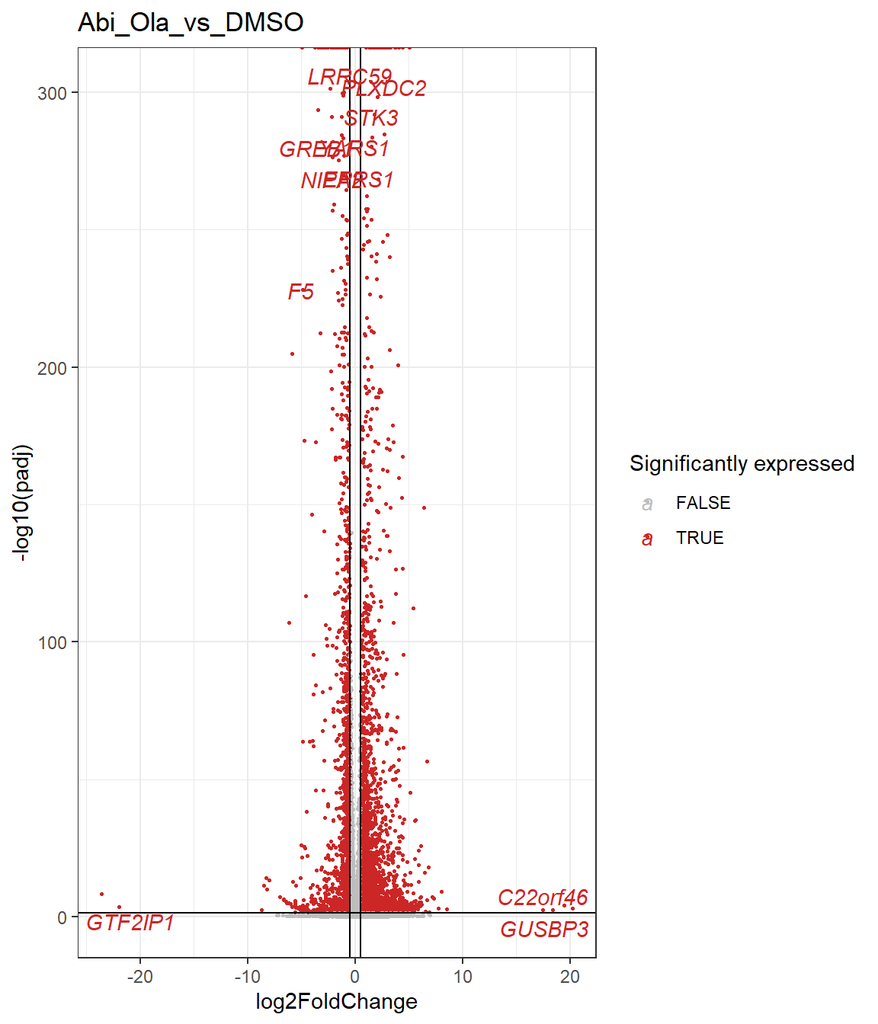

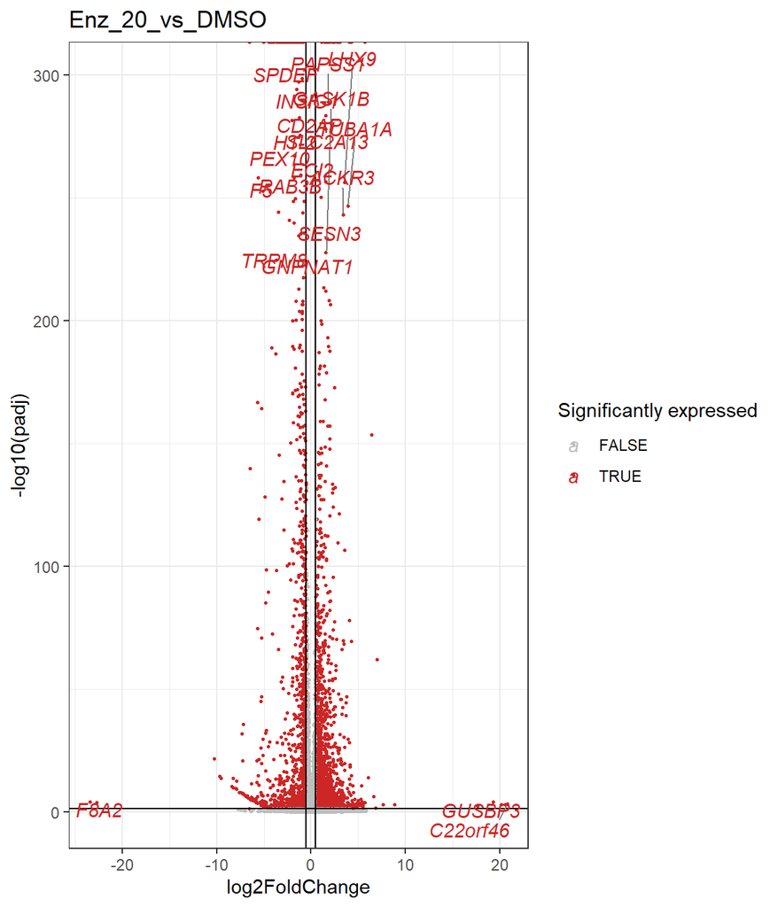

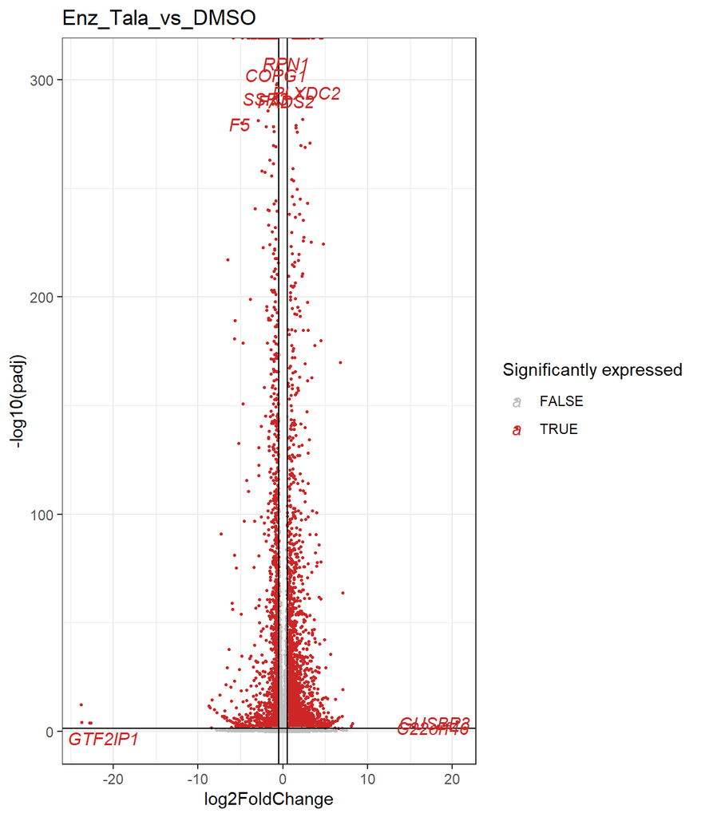

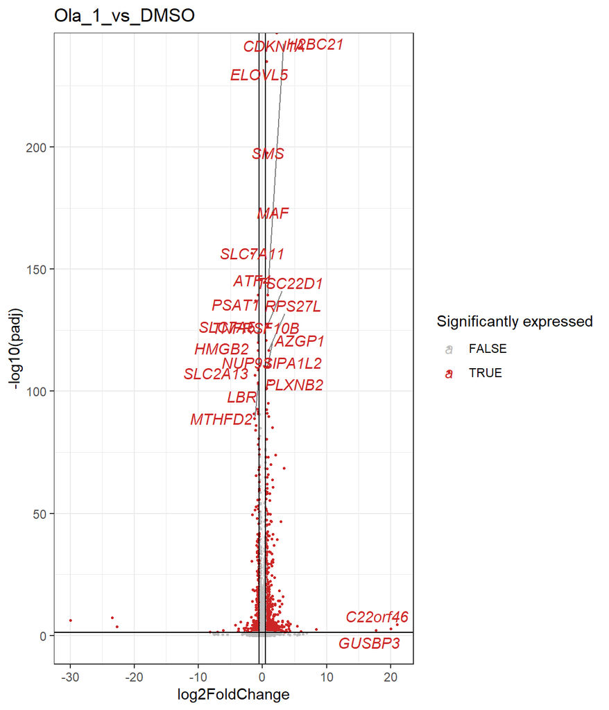

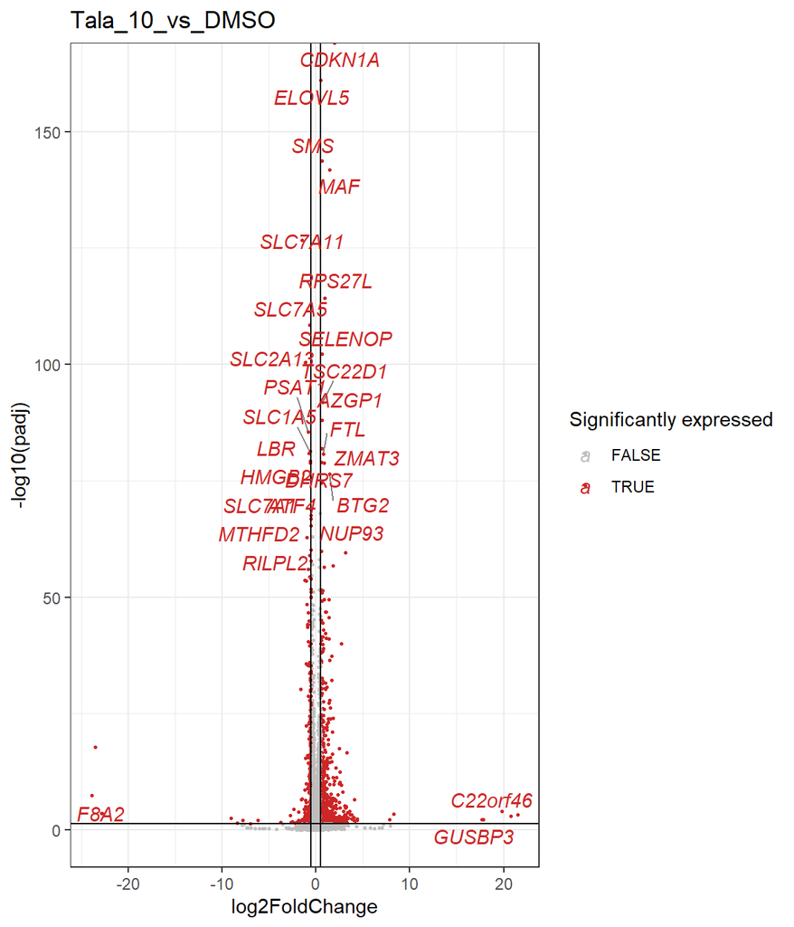